# Homework 1

Zichen Fan

2025-09-20

# Problem 1

**Loading the Data set**

```r
library(moderndive)

dat_weather=early_january_weather
```

**General Information**

```r
ncol(dat_weather)
nrow(dat_weather)

## Check important variables and value

skimr::skim(dat_weather)
```

[output not shown]

This dataset contains weather and ambient condition records for EWR (Newark Liberty International Airport) over a 15-day period in January 2013. During this time, the average temperature was 39.6°F.

The dataset consists of 358 observations and 15 variables, including key weather metrics such as temperature, humidity, wind direction, wind speed, and more. A full list of variables is provided below:

[output not shown]

**Temperature Plot**

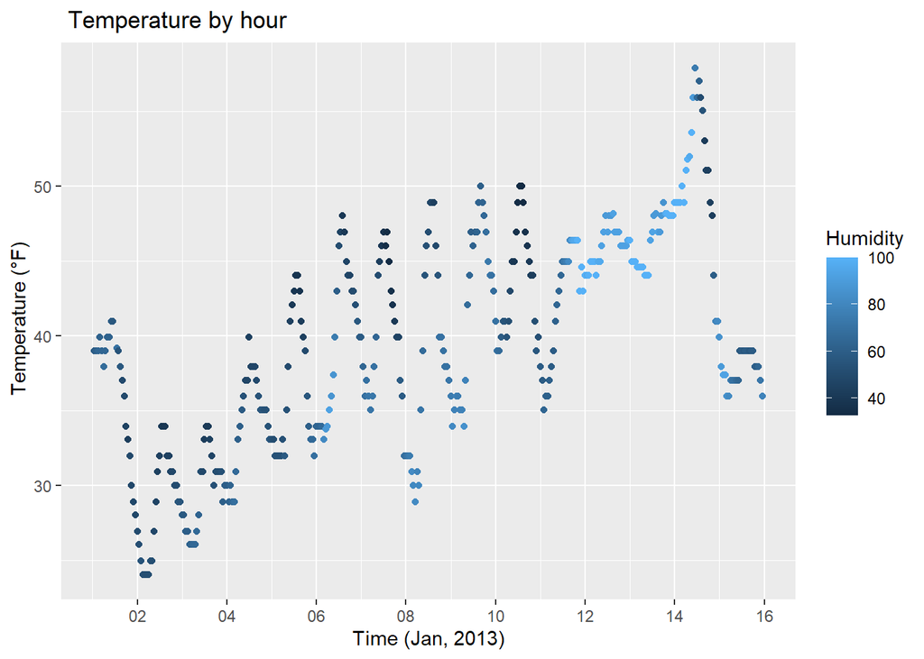

```r
library(ggplot2)

temp_plot <- ggplot(data = dat_weather,
              aes(x = time_hour, y = temp, color = humid ) )+
       geom_point()+

  ## name the plot and axis
       labs(title = " Temperature by hour ",
         x = "Time (Jan, 2013)",
         y = " Temperature (°F)",
         color = "Humidity") +

  ## adjust x axis labling
          scale_x_datetime(
    date_breaks = "2 days",
    date_labels = "%d")

temp_plot
```

# Problem 2

**Create Tibble**

```r
library(tidyverse)
df_q2<-tibble(
  ## random sample of size 10 from a standard Normal distribution
    random_normal=rnorm(10),

  ## logical vector indicating whether elements of the sample are greater than 0
    positive=random_normal>0,

  ## character vector of length 10
    character_vec=letters[1:10],

  ## factor vector of length 10, with 3 different factor “levels”
    factor_vec=factor(rep(c("Low", "Medium", "High"), length.out = 10))
 )

df_q2
```

```
## # A tibble: 10 × 4
##    random_normal positive character_vec factor_vec
##            <dbl> <lgl>    <chr>         <fct>
##  1       -0.406  FALSE    a             Low
##  2        0.184  TRUE     b             Medium
##  3        0.288  TRUE     c             High
##  4       -1.59   FALSE    d             Low
##  5        1.23   TRUE     e             Medium
##  6        0.493  TRUE     f             High
##  7        0.498  TRUE     g             Low
##  8       -0.0201 FALSE    h             Medium
##  9       -0.148  FALSE    i             High
## 10        1.09   TRUE     j             Low
```

**Calculate Mean**

Try to calculate the mean of each variable. The result shows:

random_normal → ✅ can take mean (numeric)

positive → ✅ can take mean (logical; TRUE = 1, FALSE = 0)

```r
mean(pull(df_q2, random_normal))
```

```
## [1] 0.1618154
```

```r
mean(pull(df_q2, positive))
```

```
## [1] 0.6
```

```r
mean(pull(df_q2,character_vec))
```

```
## [1] NA
```

```r
mean(pull(df_q2, factor_vec))
```

```
## [1] NA
```

Applies function to the logical, character, and factor variables to explicitly convert them to numeric variables.

```r
as.numeric(df_q2$positive)

as.numeric(df_q2$character_vec)
as.numeric(df_q2$factor_vec)
```

[output not shown]

**Analysis and Explanation**

Applying as.numeric() clarifies why the mean() function behaves differently across data types.

The logical vector is successfully coerced to 1s (for TRUE) and 0s (for FALSE). The mean() function performs this same coercion implicitly, which is why it can correctly calculate the proportion of TRUE values.

In contrast, the character vector fails coercion because non-numeric strings like “a” cannot be converted to numbers. This results in NA values, which explains why mean() also fails on this data type.

For the factor variable, as.numeric() converts it to its underlying integer codes (1, 2, 3), not its visible labels. Although these codes are numeric, they only represent categories. That is why the mean() function recognizes that averaging categorical codes is statistically invalid and returns NA as a protective measure, preventing a nonsensical calculation.